# DATA*6200_Assignment1

2024-10-01

# Section 1

```r
library(tidyverse)
```

```r
library(readxl)
library(Dict)
library(stringr)
library(ggplot2)
library(dplyr)
library(zoo)
library(maps)
# Read the survey response data.
data <- read_xlsx("/Users/marlowe/Desktop/DATA*6200 Assignment 1/data/ask_a_manager.xlsx")
```

## Data Cleaning

```r
# Rename columns for easier reference.
## yoe refers to "Years of Experience"
## salary refers to "Annual Salary"

colnames(data) <- c("time","age","industry","title","title_additinonal_context","salary","bonus","currency","other_currency","income_additional_context","country","us_state","city","overall_yoe","current_field_yoe","highest_edu","gender","race")
```

To answer the given questions, multiple columns are required to be pre-processed, such as “industry”, “salary”, “bonus”, “currency”, “other_currency”…

### Industry

```r
# Check the unique value of the column "industry"
data |>
  select(industry) |>
  unique()
```

```
## # A tibble: 1,132 × 1
##    industry
##    <chr>
##  1 Education (Higher Education)
##  2 Computing or Tech
##  3 Accounting, Banking & Finance
##  4 Nonprofits
##  5 Publishing
##  6 Education (Primary/Secondary)
##  7 Law
##  8 Health care
##  9 Utilities & Telecommunications
## 10 Business or Consulting
## # ℹ 1,122 more rows
```

The result shows more than a thousand different results of industry description, but many of them are similar or even the same to each other. A good way to categorize them is through [North American Industry Classification System (NAICS)](https://www.census.gov/naics/?58967?yearbck=2022)

```r
naics <- dict("11" = "Natural", "21" = "Energy", "22" = "Utilities", "23" = "Construction", "31-33" = "Manufacturing", "42" = "Wholesale", "44-45" = "Retail", "48-49" = "Transportation", "51" = "IT", "52" = "Finance", "53" = "Estate", "54" = "Scientific", "55" = "Enterprise", "56" = "Administrative", "61" = "Education", "62" = "Medical", "71" = "Art", "72" = "Service", "81" = "Other", "92" = "Public")

# According to NAICS, "11" = "Agriculture, Forestry, Fishing and Hunting", "21" = "Mining, Quarrying, and Oil and Gas Extraction", "22" = "Utilities", "23" = "Construction", "31-33" = "Manufacturing", "42" = "Wholesale Trade", "44-45" = "Retail Trade", "48-49" = "Transportation and Warehousing", "51" = "Information", "52" = "Finance and Insurance", "53" = "Real Estate and Rental and Leasing", "54" = "Professional, Scientific, and Technical Services", "55" = "Management of Companies and Enterprises", "56" = "Administrative and Support and Waste Management and Remediation Services", "61" = "Educational Services", "62" = "Health Care and Social Assistance", "71" = "Arts, Entertainment, and Recreation", "72" = "Accommodation and Food Services", "81" = "Other Services (except Public Administration)", "92" = "Public Administration"
```

```r
data <- data |>   # Convert strings in "industry" to lowercase for easier categorization.
  mutate(industry_lowercase = tolower(industry))

data <- data |>   # Convert strings in "title" to lowercase for easier categorization.
  mutate(title_lowercase = tolower(title))
```

```r
# Make a new column "industry_category" by categorizing from column "industry_lowercase" and "title_lowercase".
data <- mutate(data, industry_category = case_when(
  str_detect(industry_lowercase, "^agricul|^forest|^fish|^hunt") ~ " Natural",
  str_detect(title_lowercase, "^agricul|^forest|^fish|hunt") ~ "Natural",
  # This detects if the words in every cell of column "industry_lowercase" or "title_lowercase" starts with 'agircul', 'forest', 'fish' or 'hunt'. If it satisfies any of the requirements, it should be categorized into NAICS-11: Natural.
  str_detect(industry_lowercase, "^mining|^quarry|^oil|^gas") ~ "Energy",
  str_detect(title_lowercase, "^mining|^quarry|^oil|^gas") ~ "Energy",

  str_detect(industry_lowercase, "^utilities|^energy") ~ "Utilities",
  str_detect(title_lowercase, "^utilities|^energy") ~ "Utilities",

  str_detect(industry_lowercase, "^construct|^architect") ~ "Construction",
  str_detect(title_lowercase, "^construct|^architect") ~ "Construction",

  str_detect(industry_lowercase, "^manufactur") ~ "Manufacturing",
  str_detect(title_lowercase, "^manufactur") ~ "Manufacturing",

  str_detect(industry_lowercase, "^wholesale|^trade") ~ "Wholesale",
  str_detect(title_lowercase, "^wholesale|^trade") ~ "Wholesale",

  str_detect(industry_lowercase, "^retail") ~ "Retail",
  str_detect(title_lowercase, "^retail") ~ "Retail",

  str_detect(industry_lowercase, "^transport|^warehouse") ~ "Transportation",
  str_detect(title_lowercase, "^transport|^warehouse") ~ "Transportation",

  str_detect(industry_lowercase, "^infomation|^tech|^comput|^media|^digital|^data") ~ "IT",
  str_detect(title_lowercase, "^infomation|^tech|^comput|^media|^digital|^data") ~ "IT",

  str_detect(industry_lowercase, "^finance|^insuran|^business|^consult|^market|^sales|^account") ~ "Finance",
  str_detect(title_lowercase, "^finance|^insuran|^business|^consult|^market|^sales|^account") ~ "Finance",

  str_detect(industry_lowercase, "^estate|^rent|leas|^property") ~ "Estate",
  str_detect(title_lowercase, "^estate|^rent|leas|^property") ~ "Estate",

  str_detect(industry_lowercase, "^professional|^scientific|^technical|^biotech|^aerospace|^research|^environment|^engin") ~ "Scientific",
  str_detect(title_lowercase, "^professional|^scientific|^technical|^biotech|^aerospace|^research|^environment|^engin") ~ "Scientific",

  str_detect(industry_lowercase, "^company|^enterprise|^recruit|^hr|^manage|^office") ~ "Enterprise",
  str_detect(title_lowercase, "^company|^enterprise|^recruit|^hr|^manage|^office") ~ "Enterprise",

  str_detect(industry_lowercase, "^administra|support") ~ "Administrative",
  str_detect(title_lowercase, "^administra|support") ~ "Administrative",

  str_detect(industry_lowercase, "^edu|^academi|^phd|^university") ~ "Education",
  str_detect(title_lowercase, "^edu|^academi|^phd|^university|^school") ~ "Education",

  str_detect(industry_lowercase, "^health|^care|^biopharma|^medical|^pharma") ~ "Medical",
  str_detect(title_lowercase, "^health|^care|^biopharma|^medical|^pharma") ~ "Medical",

  str_detect(industry_lowercase, "^art|^entertainment|^recreation|^writ|^publish|^direct") ~ "Art",
  str_detect(title_lowercase, "^art|^entertainment|^recreation|^writ|^publish|^direct") ~ "Art",

  str_detect(industry_lowercase, "^accomodation|^food|^hopital") ~ "Service",
  str_detect(title_lowercase, "^accomodation|^food|^hopital") ~ "Service",

  str_detect(industry_lowercase, "^public|law|^social|^survey|^librar|^politic|^event|^govern") ~ "Public",
  str_detect(title_lowercase, "^public|^law|^social|^survey|^librar|^politic|^event|^govern") ~ "Public",

  TRUE ~ "Other")) #If none of the above suits the case, then it's categorized into "Other"
```

> A potential limit of this method is uncertainty and ambiguity when categorizing terms like “Administrative manager of energy department”. This is first caused by the limitation of the data. The column “industry” is collected from text input rather than multi-selections, so the interviewees can input anything they want, which would cause ambiguity for data cleaning. Secondly, this is caused by a natural attribute of human jobs that it has multiple categories, which is hard to categorize them into one single category.

### Salary

```r
data$salary[is.na(data$salary)] <- 0    # remove all the NA's
data$bonus[is.na(data$bonus)] <- 0      # remove all the NA's

data <- data |>
  mutate(total = as.numeric(salary) + as.numeric(bonus))  # Add a new column "total" by calculating the total salary. total = salary + bonus
```

Convert all kinds of currency into US Dollars for easier data analysis.

```r
data |>
  select(currency) |>
  unique()              # There are 11 different kinds of currency, with an "Other"
```

```
## # A tibble: 11 × 1
##    currency
##    <chr>
##  1 USD
##  2 GBP
##  3 CAD
##  4 EUR
##  5 AUD/NZD
##  6 Other
##  7 CHF
##  8 ZAR
##  9 SEK
## 10 HKD
## 11 JPY
```

```r
# Count the number of people who has "other" kind of currency, and calculate its proportion to the total data set.
number_of_interviewees <- count(data)
data |>
  filter(currency == "Other") |>
  summarize(count = n(), proportion = n()/as.numeric(number_of_interviewees))
```

```
## # A tibble: 1 × 2
##   count proportion
##   <int>      <dbl>
## 1   161    0.00573
```

Interviewees with “Other” kind of currency account for approximately 0.6% of the data set, we assume it should not have a significant influence on later analysis. Even if it really has a significant influence (say, we have a billionaire who don’t use any of the currency options listed), it will not contribute to the topic here, which is about the general situation of different industries.

```r
data <- mutate(data, total_salary_usd = case_when(
  str_detect(currency, "USD") ~ total * 1.00,
  str_detect(currency, "GBP") ~ total * 1.33,
  str_detect(currency, "CAD") ~ total * 0.74,
  str_detect(currency, "EUR") ~ total * 1.11,
  str_detect(currency, "AUD") ~ total * 0.69,
  str_detect(currency, "NZD") ~ total * 0.63,
  str_detect(currency, "CHF") ~ total * 1.18,
  str_detect(currency, "ZAR") ~ total * 0.057,
  str_detect(currency, "SEK") ~ total * 0.097,
  str_detect(currency, "HKD") ~ total * 0.13,
  str_detect(currency, "JPY") ~ total * 0.007,
  TRUE ~ NA_real_)) # "Other" will not be included for future analysis.
```

### Time

```r
data$time <- as.POSIXct(data$time, format = "%Y-%m-%d %H:%M:%S") # Format the "time" column for extraction.
data <- data |>
    mutate(year = format(data$time, "%Y")) |>                    # Extract year
    mutate(month = format(data$time, "%m")) |>                   # Extract month
    mutate(year_month = format(data$time, "%Y-%m")) |>           # Extract year_month
    mutate(year_month_day = format(data$time, "%Y-%m-%d"))       # Extract year_month_day
```

### Geography

```r
data_us <- data |>
    filter(is.na(us_state) != TRUE)     # Filter the interviewees in USA.
```

```r
data_us <- data_us |>
    mutate(states = case_when(
        str_detect(us_state, "^Alabama") ~ "Alabama",
        str_detect(us_state, "^Alaska") ~ "Alaska",
        str_detect(us_state, "^Arizona") ~ "Arizona",
        str_detect(us_state, "^Arkansas") ~ "Arkansas",
        str_detect(us_state, "^California") ~ "California",
        str_detect(us_state, "^Colorado") ~ "Colorado",
        str_detect(us_state, "^Connecticut") ~ "Connecticut",
        str_detect(us_state, "^Delaware") ~ "Delaware",
        str_detect(us_state, "^Florida") ~ "Florida",
        str_detect(us_state, "^Georgia") ~ "Georgia",
        str_detect(us_state, "^Hawaii") ~ "Hawaii",
        str_detect(us_state, "^Idaho") ~ "Idaho",
        str_detect(us_state, "^Illinois") ~ "Illinois",
        str_detect(us_state, "^Indiana") ~ "Indiana",
        str_detect(us_state, "^Iowa") ~ "Iowa",
        str_detect(us_state, "^Kansas") ~ "Kansas",
        str_detect(us_state, "^Kentucky") ~ "Kentucky",
        str_detect(us_state, "^Louisiana") ~ "Louisiana",
        str_detect(us_state, "^Maine") ~ "Maine",
        str_detect(us_state, "^Maryland") ~ "Maryland",
        str_detect(us_state, "^Massachusetts") ~ "Massachusetts",
        str_detect(us_state, "^Michigan") ~ "Michigan",
        str_detect(us_state, "^Minnesota") ~ "Minnesota",
        str_detect(us_state, "^Mississippi") ~ "Mississippi",
        str_detect(us_state, "^Missouri") ~ "Missouri",
        str_detect(us_state, "^Montana") ~ "Montana",
        str_detect(us_state, "^Nebraska") ~ "Nebraska",
        str_detect(us_state, "^Nevada") ~ "Nevada",
        str_detect(us_state, "^New Hampshire") ~ "New Hampshire",
        str_detect(us_state, "^New Jersey") ~ "New Jersey",
        str_detect(us_state, "^New Mexico") ~ "New Mexico",
        str_detect(us_state, "^New York") ~ "New York",
        str_detect(us_state, "^North Carolina") ~ "North Carolina",
        str_detect(us_state, "^North Dakota") ~ "North Dakota",
        str_detect(us_state, "^Ohio") ~ "Ohio",
        str_detect(us_state, "^Oklahoma") ~ "Oklahoma",
        str_detect(us_state, "^Oregon") ~ "Oregon",
        str_detect(us_state, "^Pennsylvania") ~ "Pennsylvania",
        str_detect(us_state, "^Rhode Island") ~ "Rhode Island",
        str_detect(us_state, "^South Carolina") ~ "South Carolina",
        str_detect(us_state, "^South Dakota") ~ "South Dakota",
        str_detect(us_state, "^Tennessee") ~ "Tennessee",
        str_detect(us_state, "^Texas") ~ "Texas",
        str_detect(us_state, "^Utah") ~ "Utah",
        str_detect(us_state, "^Vermont") ~ "Vermont",
        str_detect(us_state, "^Virginia") ~ "Virginia",
        str_detect(us_state, "^Washington") ~ "Washington",
        str_detect(us_state, "^West Virginia|^District") ~ "West Virginia",
        str_detect(us_state, "^Wisconsin") ~ "Wisconsin",
        str_detect(us_state, "^Wyoming") ~ "Wyoming",
        TRUE ~ "Other"))
```

This step might seems unnecessary but it for correcting the name of US states, because people have typos in their answers.

```r
# Check if there are unsorted terms.
data_us |>
    select(states) |>
    unique()
```

```
## # A tibble: 50 × 1
##    states
##    <chr>
##  1 Massachusetts
##  2 Tennessee
##  3 Wisconsin
##  4 South Carolina
##  5 New Hampshire
##  6 Arizona
##  7 Missouri
##  8 Florida
##  9 Pennsylvania
## 10 Michigan
## # ℹ 40 more rows
```

```r
data_us |>
    filter(states == "Other") |>
    count()    # Check if there are unsorted states.
```

```
## # A tibble: 1 × 1
##       n
##   <int>
## 1     0
```

## Industry with Highest/Lowest Salary

From here, we start to answer the first question. “Which industry or industries have the highest/lowest salaries?”

```r
filtered_data <- data |>      # filtered_data means data with top2.5% and bottom 2.5% removed.
  filter(currency != "Other"
         & total_salary_usd >= quantile(data$total_salary_usd, 0.025, na.rm = TRUE)
         & total_salary_usd <= quantile(data$total_salary_usd, 0.975, na.rm = TRUE))
```

During the analysis process, some significantly unusual data with exceptionally high/low total salary is detected. So for the interpretability of the analysis result, the top 2.5% and bottom 2.5% of the data$total_salary_usd are removed.

```r
salary_summary <- filtered_data |>
  select(industry_category, total_salary_usd) |>
  group_by(industry_category) |>
  summarise(mean_salary = mean(total_salary_usd)) |>
  arrange(desc(mean_salary))

top_bottom_2 <- salary_summary |>
    slice_max(mean_salary, n = 2) |>       # Check the highest 2 values
    bind_rows(                             # Combine the two sliced rows into one data frame.
        salary_summary |>
            slice_min(mean_salary, n = 2)) # Check the lowest 2 values

top_bottom_2 |>
    arrange(desc(mean_salary))
```

```
## # A tibble: 4 × 2
##   industry_category mean_salary
##   <chr>                   <dbl>
## 1 IT                    112344.
## 2 Utilities              95902.
## 3 Service                65243.
## 4 Administrative         53695.
```

The analysis shows that among all the job categories of NAICS, jobs related to *IT*,*Computing* and *Technology* have the **highest** average annual salary of about *112k* USD. And jobs related to *energy* and *utilities* have the second highest salary, on average.

# Section 2 Data Visualization

From here, the second question “Which industries have the highest salary variability?” will be answered.

## Industry with Highest Variability

```r
summary_filtered_data <- filtered_data  |>
  select(industry_category, total_salary_usd) |>
  group_by(industry_category) |>
  summarise(
    mean_salary = mean(total_salary_usd), # mean
    sd_salary = sd(total_salary_usd),     # standard deviation
    cv_salary = sd_salary / mean_salary,  # coefficient of variation
    iqr_salary = IQR(total_salary_usd),   # interquartile range
    range_salary = max(total_salary_usd) - min(total_salary_usd))
```

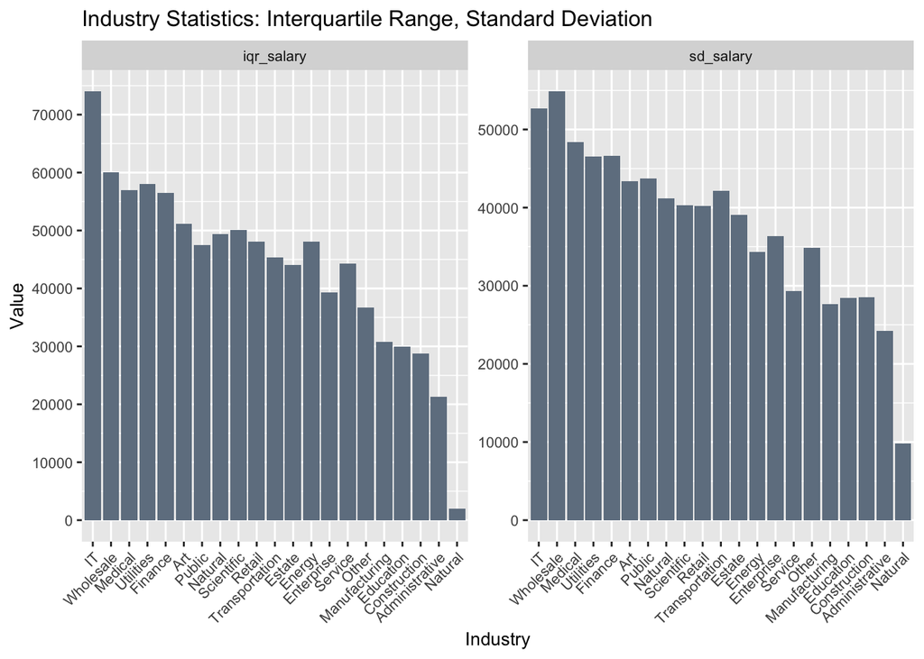

```r
summary_filtered_data |>
    pivot_longer(cols = c(sd_salary, iqr_salary), # pivot the data longer
                 names_to = "statistic",
                 values_to = "value") |>
    ggplot(aes(x = reorder(industry_category, -value),y = value)) +
    geom_bar(stat = "identity", fill = "slategrey") +
    facet_wrap(~statistic, scales = "free_y") +
    labs(title = "Industry Statistics: Interquartile Range, Standard Deviation",
         x = "Industry",
         y = "Value") +
    scale_y_continuous(n.breaks = 10) +
    theme(axis.text.x = element_text(angle = 45, hjust = 1),   # Rotate x-axis labels
          text = element_text(size = 10))
```

The interquartile range (IQR) measures the spread of middle 50% of the data, which is a great way to look into variability of a specific industry. And the standard deviation shows how the data of each industry vary from the mean value.

The result shows that among all the 20 industries, **IT**, **Wholesale**, **Medical**, **Utilities**, and **Finance** have the highest variability. These industries has the largest interquartile value and standard deviation, which indicates that salary of people working in these industries spreads over a wide range.

However, this data set has a chronological attribute, which can be interpreted as how the salary fluctuated over a range of time (2021-2024). This means the data of each industry might not be symmetric, which may decrease the interpretability of standard deviation.

In order to deal with this potential problem, we look at another metric, which the proportion between the lowest 25% and the highest 25% of the industries.

```r
proportion_summary  <- filtered_data |>
    select(industry_category, total_salary_usd) |>
    group_by(industry_category) |>
    summarize(
        top25_avg = mean(
            total_salary_usd[total_salary_usd >= quantile(total_salary_usd, 0.75)]),
        bot25_avg = mean(
            total_salary_usd[total_salary_usd <= quantile(total_salary_usd, 0.25)]),
        proportion = bot25_avg / top25_avg) |>
    arrange(desc(proportion))

proportion_summary |>
    slice_max(proportion, n = 1) |>        # Check the highest 2 values
    bind_rows(                             # Combine the two sliced rows into one data frame.
        proportion_summary |>
            slice_min(proportion, n = 1))  # Check the lowest 2 values
```

```
## # A tibble: 2 × 4
##   industry_category top25_avg bot25_avg proportion
##   <chr>                 <dbl>     <dbl>      <dbl>
## 1 Natural             100280.    85434.      0.852
## 2 Wholesale           163890.    40997.      0.250
```

Let’s look more into the difference between the top industries and bottom industries.

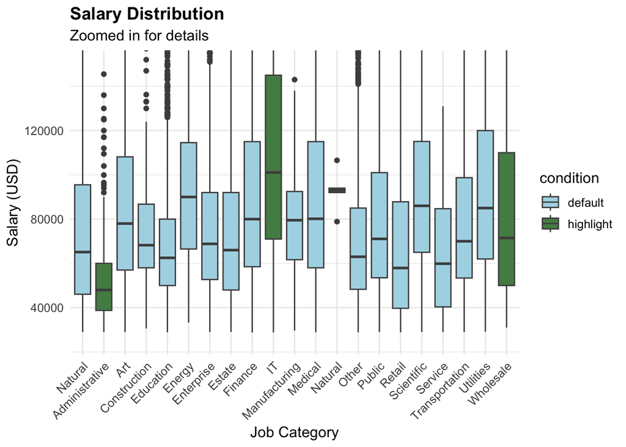

```r
condition = ifelse(filtered_data$industry_category %in% c("IT", "Administrative", "Natural", "Wholesale"), "highlight", "default")
filtered_data |>
  ggplot(aes(x = industry_category, y = total_salary_usd,
             fill = condition)) +
    geom_boxplot(color = "grey30") +
    labs(title = "Salary Distribution",
         subtitle = "Zoomed in for details",
         x = "Job Category",
         y = "Salary (USD)") +
    theme_minimal() +
    theme(axis.text.x = element_text(angle = 45, hjust = 1),
         text = element_text(size = 12),
          plot.title = element_text(size = 14, face = "bold"),) +
    coord_cartesian(ylim = c(25000, 150000)) +  # Adjust this range to "zoom in"
    scale_fill_manual(values = c("highlight" = "palegreen4", "default" = "lightblue"))
```

Notice the huge gap between job salaries in IT industry and Administrative Industry. Another thing that is worth mentioning is that notice the pattern “Natural” industry is almost indistinguishable, showing that the 0.75 quartile is almost the same as 0.25 quartile, which also supports the conclusion we found above that “Natural” jobs don’t vary a lot in salary.

> A potential limit of this graph is that it doesn’t show how the salaries in “*Wholesale*” industry vary a lot. The top 25% people in Wholesale earns almost three times more than the bottom 25% average. And that is not showed here because the graph is zoomed in to ingore the unusually high salary data points for visability and interpretability.

##Salaries Vary Over Time and Geography

From here, the third question “How do salaries vary over time and geography?” is answered.

### Salaries Vary Over Time

Before we dive into the question, we need to look into a problem in the data set.

```r
# Count the data by year_month
filtered_data |>
    select(year_month, total_salary_usd) |>
    group_by(year_month) |>
    summarize(count = n(),
              mean = mean(total_salary_usd))
```

```
## # A tibble: 41 × 3
##    year_month count   mean
##    <chr>      <int>  <dbl>
##  1 2021-04    21564 89066.
##  2 2021-05     3437 91037.
##  3 2021-06      111 91303.
##  4 2021-07       70 88337.
##  5 2021-08      139 89354.
##  6 2021-09       49 94137.
##  7 2021-10      641 86358.
##  8 2021-11       74 88857.
##  9 2021-12       47 83804.
## 10 2022-01       41 92263.
## # ℹ 31 more rows
```

As the time gets closer to 2024, observations of salaries reported get less and less. We have about 20 categories of industry, but in some of the months listed, the data set only has 100 observations or even less! Can they fully represent the 20 industries? Clearly no, they can’t even give a general evaluation of the whole society during that time period.

Thus, in my opinion, it’s not possible to look into how salaries vary over time from this data set, at least not accurately. However, we can still look into it to get a general view of the changes among time with the expectations of inaccuracy among data in later months.

```r
over_time <- filtered_data |>
    select(year_month, year_month_day, industry_category, total_salary_usd) |>
    group_by(year_month, industry_category) |>
    summarize(average_salary = mean(total_salary_usd, na.rm = TRUE), .groups = "drop")

over_time
```

```
## # A tibble: 316 × 3
##    year_month industry_category average_salary
##    <chr>      <chr>                      <dbl>
##  1 2021-04    " Natural"                78319.
##  2 2021-04    "Administrative"          53616.
##  3 2021-04    "Art"                     88676.
##  4 2021-04    "Construction"            76170.
##  5 2021-04    "Education"               68507.
##  6 2021-04    "Energy"                  87360.
##  7 2021-04    "Enterprise"              77207.
##  8 2021-04    "Estate"                  74163.
##  9 2021-04    "Finance"                 92189.
## 10 2021-04    "IT"                     112555.
## # ℹ 306 more rows
```

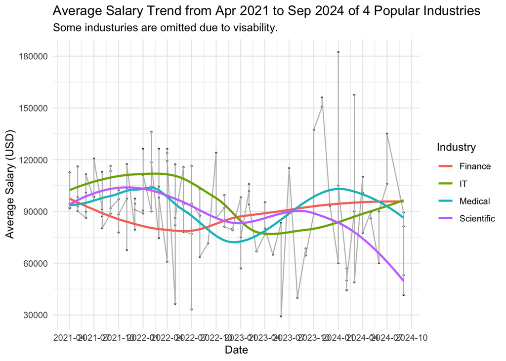

```r
over_time <- filtered_data |>
    mutate(year_month = as.Date(paste0(year_month, "-01")))
over_time |>
    select(year_month, industry_category, total_salary_usd) |>
    filter(industry_category %in% c("IT", "Scientific", "Medical", "Finance")) |>
    group_by(year_month, industry_category,.groups = "drop") |>
    summarize(mean = mean(total_salary_usd)) |>
    ggplot(mapping = aes(x = year_month,
                         y = mean,
                         col = industry_category)) +
    geom_point(color = "black", size = 0.3) +
    geom_line(color = "grey") +
    geom_smooth(method = "loess", se = FALSE)+
    scale_x_date(date_breaks = "3 month", date_labels = "%Y-%m") +
    scale_y_continuous(n.breaks = 7) +
    labs(title = "Average Salary Trend from Apr 2021 to Sep 2024 of 4 Popular Industries",
         subtitle = "Some industuries are omitted due to visability.",
         x = "Date",
         y = "Average Salary (USD)",
         color = "Industry") +
    theme(axis.text.x = element_text(angle = 45, hjust = 1),
          plot.title = element_text(size = 12, face = "bold"),
          text = element_text(size = 12))+
    theme_minimal()
```

From the graph we can see how the average salary of IT, Medical, and Scientific industry fluctuated during the pandemic. Also notice that how the Finance industry dropped at first but came back later, which can be a signal of how the global economy gradually recovered from the depression caused by pandemic.

### Vary Over Geography

```r
filtered_data |>
    select(country) |>
    group_by(country) |>
    summarize(count = n()) |>
    arrange(desc(count))
```

```
## # A tibble: 270 × 2
##    country                  count
##    <chr>                    <int>
##  1 United States             9251
##  2 USA                       8036
##  3 US                        2495
##  4 Canada                    1563
##  5 United Kingdom             580
##  6 U.S.                       578
##  7 UK                         551
##  8 United States of America   458
##  9 Usa                        437
## 10 Australia                  376
## # ℹ 260 more rows
```

We can see that the majority of the interviewees in this survey come from United States, so we’ll look into how salaries vary over United States.

```r
data_us_filtered <- data_us |>
  filter(currency != "Other"
         & total_salary_usd >= quantile(data$total_salary_usd, 0.025, na.rm = TRUE)
         & total_salary_usd <= quantile(data$total_salary_usd, 0.975, na.rm = TRUE))

us_summary <- data_us_filtered |>
    select(industry_category, states, total_salary_usd) |>
    filter(is.na(data_us_filtered$states) != TRUE) |>
    group_by(states) |>
    summarise(mean_salary = mean(total_salary_usd, na.rm = TRUE)) |>
    arrange(desc(mean_salary))
us_summary
```

```
## # A tibble: 50 × 2
##    states        mean_salary
##    <chr>               <dbl>
##  1 California        113428.
##  2 Washington        106943.
##  3 New York          102574.
##  4 Massachusetts     100562.
##  5 West Virginia      99440.
##  6 Virginia           95517.
##  7 Maryland           93603.
##  8 Texas              92473.
##  9 Oregon             92345.
## 10 New Jersey         92263.
## # ℹ 40 more rows
```

```r
california_summary <- data_us_filtered |>
    filter(states == "California") |>
    group_by(industry_category) |>
    summarise(mean_salary = mean(total_salary_usd, na.rm = TRUE)) |>
    slice_max(mean_salary, n = 1) # Get the industry with the highest salalry in California
california_summary
```

```
## # A tibble: 1 × 2
##   industry_category mean_salary
##   <chr>                   <dbl>
## 1 IT                    143779.
```

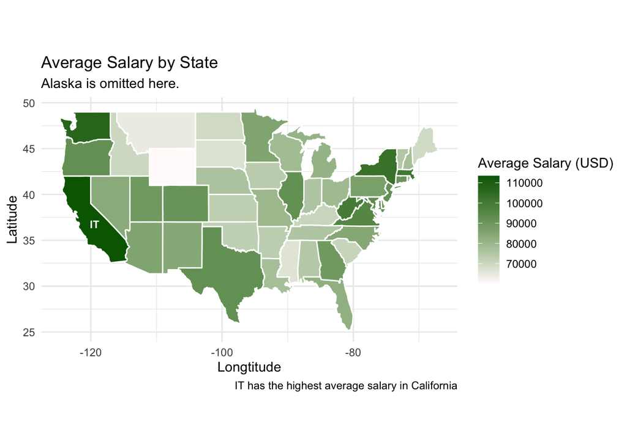

```r
us_map <- map_data("state")                           # Choose map

us_summary$states <- tolower(us_summary$states)       # Convert lowercase to match the map

us_map_summary <- us_map |>
  left_join(us_summary, by = c("region" = "states"))

label_position <- data.frame(
  state = "California",
  long = -119.4179,                                   # Longitude for California
  lat = 36.7783,                                      # Latitude for California
  label = "IT")

us_map_summary |>
    ggplot(aes(x = long, y = lat,
           group = us_map_summary$group,
           fill = us_map_summary$mean_salary)) +
    geom_polygon(color = "white") +                   # Add state borders
    coord_fixed(1.4) +                                # Fix aspect ratio
    labs(x = "Longtitude",
         y = "Latitude",
         title = "Average Salary by State",
         subtitle = "Alaska is omitted here.",
         fill = "Average Salary (USD)",
         caption = "IT has the highest average salary in California") +
    theme_minimal() +  # Remove background and grid lines.
    scale_fill_gradient(low = "snow", high = "darkgreen") +
    geom_text(data = label_position, aes(x = long, y = lat, label = label),
              color = "snow", size = 3, fontface = "bold",inherit.aes = FALSE)
```

> Possible improvement: add labels for every states showing the industry wiht highest salaries in that state.